# Moneyball Application: Application of a linear regression model to basketball statistics

### Assessing multicollinearity of the variables using the `pairs()` function:

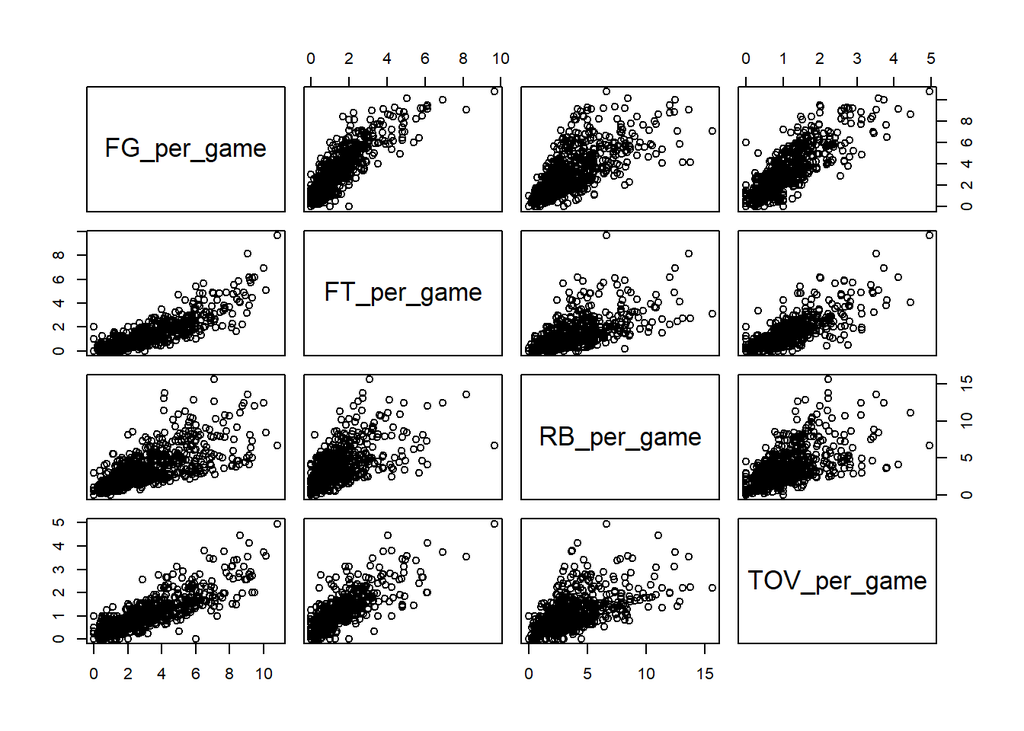

```r
pairs(formula = ~ FG_per_game + FT_per_game + RB_per_game + TOV_per_game, data = players)
```

We will also conduct a test to assess for linearity in the data using the avPlots from `car` package

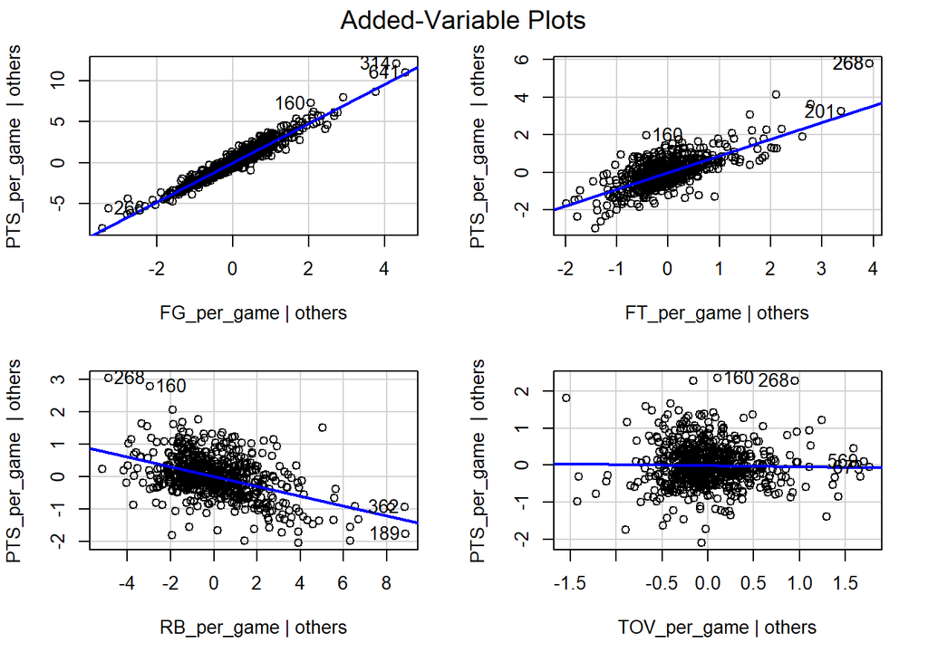

```r
car::avPlots(fit)
```

### Assessing standard error

Finally, we look to explore the standard error in our data by using the variance inflation factor `vif()` from the cars package

```r
car::vif(fit)
```

```
##  FG_per_game  FT_per_game  RB_per_game TOV_per_game
##     5.386367     4.039133     1.933118     3.489844
```

## Creating a new variable for player

We can now model an expected points per game scored by our players in the coming season and this will give us an indication of how are players are performing and its effects on the overall team efficiency. Hence we are able to better predict the outcome of our regular season

```r
players <- mutate(players, exp_PTS = predict(fit, newdata = players))
```

## Player recommendations

Firstly, let’s look at including the player salary to their object. We can complete this by using the `right_join()` function:

```r
players <- salary %>%
  select(player, salary) %>%
  right_join(players, by = "player")
```

We then group the players based on their position by using the `filter()` function:

```r
## PG
players_PG <- filter(players, Pos == "PG")
players_PG
```

```
## # A tibble: 139 x 46
##    player     salary Pos     Age Tm        G    GS    MP    FG   FGA   FGp   x3P
##    <chr>       <dbl> <chr> <dbl> <chr> <dbl> <dbl> <dbl> <dbl> <dbl> <dbl> <dbl>
##  1 Aaron Hol~ 1.91e6 PG       22 IND      50     0   646   105   262 0.401    43
##  2 Alex Caru~ 7.72e4 PG       24 LAL      25     4   531    77   173 0.445    24
##  3 Andrew Ha~ 3.54e5 PG       24 MEM       1     0     5     1     2 0.5       0
##  4 Andrew Ha~ 3.54e5 PG       24 NOP       6     0    38     3    12 0.25      2
##  5 Andrew Ha~ 3.54e5 PG       24 CLE      10     0   144    12    39 0.308     3
##  6 Andrew Ha~ 3.54e5 PG       24 TOT      17     0   187    16    53 0.302     5
##  7 Ben Simmo~ 6.43e6 PG       22 PHI      79    79  2700   540   960 0.563     0
##  8 Brad Wana~ 8.38e5 PG       29 BOS      36     0   343    50   105 0.476    16
##  9 Brandon G~ 5.68e4 PG       23 DEN      16     0    57     6    23 0.261     2
## 10 Brandon K~ 1.46e7 PG       27 HOU      12     0   118    11    47 0.234     5
## # ... with 129 more rows, and 34 more variables: x3PA <dbl>, x3Pp <dbl>,
## #   x2P <dbl>, x2PA <dbl>, x2Pp <dbl>, eFGp <dbl>, FT <dbl>, FTA <dbl>,
## #   FTp <dbl>, ORB <dbl>, DRB <dbl>, TRB <dbl>, AST <dbl>, STL <dbl>,
## #   BLK <dbl>, TOV <dbl>, PF <dbl>, PTS <dbl>, PTS_per_min <dbl>,
## #   PPM_category <chr>, FG_z <dbl>, FG_category <chr>, RB_per_game <dbl>,
## #   RB_category <chr>, TOV_per_game <dbl>, TOV_category <chr>,
## #   AST_per_game <dbl>, AST_category <chr>, FG_per_game <dbl>,
## #   x3P_per_game <dbl>, x2P_per_game <dbl>, FT_per_game <dbl>,
## #   PTS_per_game <dbl>, exp_PTS <dbl>
```

```r
## SG
players_SG <- filter(players, Pos == "SG")
players_SG
```

```
## # A tibble: 176 x 46
##    player     salary Pos     Age Tm        G    GS    MP    FG   FGA   FGp   x3P
##    <chr>       <dbl> <chr> <dbl> <chr> <dbl> <dbl> <dbl> <dbl> <dbl> <dbl> <dbl>
##  1 Alec Burks 1.15e7 SG       27 SAC      13     0   127     9    20 0.45      0
##  2 Alec Burks 1.15e7 SG       27 UTA      17     0   269    47   114 0.412    16
##  3 Alec Burks 1.15e7 SG       27 CLE      34    24   979   136   340 0.4      45
##  4 Alec Burks 1.15e7 SG       27 TOT      64    24  1375   192   474 0.405    61
##  5 Alex Abri~ 3.67e6 SG       25 OKC      31     2   588    56   157 0.357    41
##  6 Allen Cra~ 1.93e7 SG       26 BRK      43    20  1133   137   373 0.367    98
##  7 Allonzo T~ 3.38e6 SG       23 NYK      64     3  1459   232   518 0.448    52
##  8 Andre Ing~ 7.62e4 SG       33 LAL       4     0    15     0     6 0         0
##  9 Anfernee ~ 1.84e6 SG       19 POR      20     1   141    28    63 0.444    10
## 10 Antonio B~ 1.35e6 SG       22 CHI      57     3   829   166   396 0.419    36
## # ... with 166 more rows, and 34 more variables: x3PA <dbl>, x3Pp <dbl>,
## #   x2P <dbl>, x2PA <dbl>, x2Pp <dbl>, eFGp <dbl>, FT <dbl>, FTA <dbl>,
## #   FTp <dbl>, ORB <dbl>, DRB <dbl>, TRB <dbl>, AST <dbl>, STL <dbl>,
## #   BLK <dbl>, TOV <dbl>, PF <dbl>, PTS <dbl>, PTS_per_min <dbl>,
## #   PPM_category <chr>, FG_z <dbl>, FG_category <chr>, RB_per_game <dbl>,
## #   RB_category <chr>, TOV_per_game <dbl>, TOV_category <chr>,
## #   AST_per_game <dbl>, AST_category <chr>, FG_per_game <dbl>,
## #   x3P_per_game <dbl>, x2P_per_game <dbl>, FT_per_game <dbl>,
## #   PTS_per_game <dbl>, exp_PTS <dbl>
```

```r
## SF
players_SF <- filter(players, Pos == "SF")
players_SF
```

```
## # A tibble: 118 x 46
##    player     salary Pos     Age Tm        G    GS    MP    FG   FGA   FGp   x3P
##    <chr>       <dbl> <chr> <dbl> <chr> <dbl> <dbl> <dbl> <dbl> <dbl> <dbl> <dbl>
##  1 Abdel Nad~ 1.38e6 SF       25 OKC      61     1   694    91   215 0.423    32
##  2 Alfonzo M~ 1.35e6 SF       26 GSW      72     5  1003   134   275 0.487    42
##  3 Andre Igu~ 1.60e7 SF       35 GSW      68    13  1578   151   302 0.5      48
##  4 Andrew Wi~ 2.55e7 SF       23 MIN      73    73  2543   498  1209 0.412   118
##  5 BJ Johnson 1.42e5 SF       23 SAC       1     0     6     1     2 0.5       0
##  6 BJ Johnson 1.42e5 SF       23 ATL       6     0    43     8    16 0.5       3
##  7 BJ Johnson 1.42e5 SF       23 TOT       7     0    49     9    18 0.5       3
##  8 Bojan Bog~ 1.05e7 SF       29 IND      81    81  2573   522  1051 0.497   164
##  9 Bonzie Co~ 7.72e4 SF       23 MIL       8     2    98    13    39 0.333     5
## 10 Brandon I~ 5.76e6 SF       21 LAL      52    52  1760   362   729 0.497    31
## # ... with 108 more rows, and 34 more variables: x3PA <dbl>, x3Pp <dbl>,
## #   x2P <dbl>, x2PA <dbl>, x2Pp <dbl>, eFGp <dbl>, FT <dbl>, FTA <dbl>,
## #   FTp <dbl>, ORB <dbl>, DRB <dbl>, TRB <dbl>, AST <dbl>, STL <dbl>,
## #   BLK <dbl>, TOV <dbl>, PF <dbl>, PTS <dbl>, PTS_per_min <dbl>,
## #   PPM_category <chr>, FG_z <dbl>, FG_category <chr>, RB_per_game <dbl>,
## #   RB_category <chr>, TOV_per_game <dbl>, TOV_category <chr>,
## #   AST_per_game <dbl>, AST_category <chr>, FG_per_game <dbl>,
## #   x3P_per_game <dbl>, x2P_per_game <dbl>, FT_per_game <dbl>,
## #   PTS_per_game <dbl>, exp_PTS <dbl>
```

```r
## PF
players_PF <- filter(players, Pos == "PF")
players_PF
```

```
## # A tibble: 147 x 46
##    player     salary Pos     Age Tm        G    GS    MP    FG   FGA   FGp   x3P
##    <chr>       <dbl> <chr> <dbl> <chr> <dbl> <dbl> <dbl> <dbl> <dbl> <dbl> <dbl>
##  1 Aaron Gor~ 2.16e7 PF       23 ORL      78    78  2633   470  1046 0.449   121
##  2 Alan Will~ 7.72e4 PF       26 BRK       5     0    26     8    13 0.615     0
##  3 Alex Poyt~ 7.72e4 PF       25 ATL      21     1   305    40    81 0.494     9
##  4 Al-Farouq~ 6.96e6 PF       28 POR      81    81  2292   257   593 0.433    96
##  5 Alize Joh~ 8.38e5 PF       22 IND      14     0    64     4    16 0.25      1
##  6 Amile Jef~ 7.72e4 PF       25 ORL      12     0    68    10    16 0.625     0
##  7 Anthony T~ 5.75e6 PF       33 MIN      65     0  1079    99   259 0.382    81
##  8 Blake Gri~ 3.19e7 PF       29 DET      75    75  2622   619  1341 0.462   189
##  9 Bobby Por~ 2.49e6 PF       23 CHI      22     6   531   122   271 0.45     27
## 10 Bobby Por~ 2.49e6 PF       23 WAS      28    22   768   157   357 0.44     48
## # ... with 137 more rows, and 34 more variables: x3PA <dbl>, x3Pp <dbl>,
## #   x2P <dbl>, x2PA <dbl>, x2Pp <dbl>, eFGp <dbl>, FT <dbl>, FTA <dbl>,
## #   FTp <dbl>, ORB <dbl>, DRB <dbl>, TRB <dbl>, AST <dbl>, STL <dbl>,
## #   BLK <dbl>, TOV <dbl>, PF <dbl>, PTS <dbl>, PTS_per_min <dbl>,
## #   PPM_category <chr>, FG_z <dbl>, FG_category <chr>, RB_per_game <dbl>,
## #   RB_category <chr>, TOV_per_game <dbl>, TOV_category <chr>,
## #   AST_per_game <dbl>, AST_category <chr>, FG_per_game <dbl>,
## #   x3P_per_game <dbl>, x2P_per_game <dbl>, FT_per_game <dbl>,
## #   PTS_per_game <dbl>, exp_PTS <dbl>
```

```r
## C
players_C <- filter(players, Pos == "C")
players_C
```

```
## # A tibble: 120 x 46
##    player     salary Pos     Age Tm        G    GS    MP    FG   FGA   FGp   x3P
##    <chr>       <dbl> <chr> <dbl> <chr> <dbl> <dbl> <dbl> <dbl> <dbl> <dbl> <dbl>
##  1 Al Horford 2.89e7 C        32 BOS      68    68  1973   387   723 0.535    73
##  2 Alex Len   4.35e6 C        25 ATL      77    31  1544   320   648 0.494    74
##  3 Amir John~ 2.39e6 C        31 PHI      51     6   529    79   157 0.503    12
##  4 Andre Dru~ 2.54e7 C        25 DET      79    79  2647   561  1052 0.533     5
##  5 Andrew Bo~ 4.87e5 C        34 GSW      11     5   134    18    36 0.5       0
##  6 Angel Del~ 7.72e4 C        24 LAC       2     0    15     1     5 0.2       0
##  7 Ante Zizic 1.95e6 C        22 CLE      59    25  1082   183   331 0.553     0
##  8 Anthony D~ 2.54e7 C        25 NOP      56    56  1850   530  1026 0.517    48
##  9 Aron Bayn~ 5.19e6 C        32 BOS      51    18   821   105   223 0.471    21
## 10 Bam Adeba~ 2.96e6 C        21 MIA      82    28  1913   280   486 0.576     3
## # ... with 110 more rows, and 34 more variables: x3PA <dbl>, x3Pp <dbl>,
## #   x2P <dbl>, x2PA <dbl>, x2Pp <dbl>, eFGp <dbl>, FT <dbl>, FTA <dbl>,
## #   FTp <dbl>, ORB <dbl>, DRB <dbl>, TRB <dbl>, AST <dbl>, STL <dbl>,
## #   BLK <dbl>, TOV <dbl>, PF <dbl>, PTS <dbl>, PTS_per_min <dbl>,
## #   PPM_category <chr>, FG_z <dbl>, FG_category <chr>, RB_per_game <dbl>,
## #   RB_category <chr>, TOV_per_game <dbl>, TOV_category <chr>,
## #   AST_per_game <dbl>, AST_category <chr>, FG_per_game <dbl>,
## #   x3P_per_game <dbl>, x2P_per_game <dbl>, FT_per_game <dbl>,
## #   PTS_per_game <dbl>, exp_PTS <dbl>
```

```r
gg <- players %>%
  ggplot(aes(x = salary/1000000, y = exp_PTS, colour = Pos)) +
  geom_point() +
  xlab("Salary (Millions)")
```

In order to further assess these traits for our individual athletes by position, we can use the `select()`, `arrange()` and `top_n()` functions to select our top performers by position. A top_n(15) has been used so that we can select players who are still within the top quartile of their position but able to perform off the bench

```r
players_PG %>%
  select(player, salary, AST_category, TOV_category, x3P_per_game, exp_PTS) %>%
  arrange(desc(exp_PTS), salary) %>%
  top_n(15)
```

```
## # A tibble: 15 x 6
##    player              salary AST_category  TOV_category  x3P_per_game exp_PTS
##    <chr>                <dbl> <chr>         <chr>                <dbl>   <dbl>
##  1 James Harden      30570000 above average above average         4.85    33.8
##  2 Damian Lillard    27977689 above average above average         2.96    25.3
##  3 Kemba Walker      12000000 above average above average         3.17    25.2
##  4 Stephen Curry     37457154 above average above average         5.13    24.9
##  5 Kyrie Irving      20099189 above average above average         2.60    24.1
##  6 Russell Westbrook 35665000 above average above average         1.63    22.9
##  7 John Wall         19169800 above average above average         1.59    21.5
##  8 D'Angelo Russell   7019698 above average above average         2.89    21.0
##  9 Mike Conley       30521115 above average above average         2.21    21.0
## 10 Derrick Rose       2176260 above average above average         1.06    19.4
## 11 Trae Young         5363280 above average above average         1.93    19.0
## 12 Jamal Murray       3499800 above average above average         2.03    18.4
## 13 Ben Simmons        6434520 above average above average         0       18.3
## 14 De'Aaron Fox       5470920 above average above average         1.06    18.0
## 15 Collin Sexton      4073760 above average above average         1.45    17.4
```

```r
players_SG %>%
  select(player, salary, AST_category, TOV_category, x3P_per_game, exp_PTS) %>%
  arrange(desc(exp_PTS), salary) %>%
  top_n(15)
```

```
## # A tibble: 15 x 6
##    player             salary AST_category  TOV_category  x3P_per_game exp_PTS
##    <chr>               <dbl> <chr>         <chr>                <dbl>   <dbl>
##  1 Devin Booker      3314365 above average above average       2.11      27.1
##  2 Bradley Beal     25434262 above average above average       2.55      25.9
##  3 Zach LaVine      19500000 above average above average       1.90      24.2
##  4 Donovan Mitchell  3111480 above average above average       2.44      24.0
##  5 DeMar DeRozan    27739975 above average above average       0.0909    23.3
##  6 Jrue Holiday     26641111 above average above average       1.76      21.9
##  7 Jimmy Butler     19841627 above average above average       1.7       21.6
##  8 Klay Thompson    18988725 above average above average       3.09      21.4
##  9 CJ McCollum      25759766 above average above average       2.39      21.4
## 10 Lou Williams      8000000 above average above average       1.4       20.4
## 11 Luka Doncic       6569040 above average above average       2.33      20.3
## 12 Buddy Hield       3833760 above average above average       3.39      19.7
## 13 Victor Oladipo   21000000 above average above average       2.06      18.6
## 14 Tim Hardaway     17325000 above average above average       2.54      18.4
## 15 Tim Hardaway     17325000 above average above average       2.49      17.4
```

```r
players_SF %>%
  select(player, salary, AST_category, TOV_category, x3P_per_game, exp_PTS) %>%
  arrange(desc(exp_PTS), salary) %>%
  top_n(15)
```

```
## # A tibble: 15 x 6
##    player             salary AST_category  TOV_category  x3P_per_game exp_PTS
##    <chr>               <dbl> <chr>         <chr>                <dbl>   <dbl>
##  1 LeBron James     35654150 above average above average        2.02     27.9
##  2 Kawhi Leonard    23114066 above average above average        1.87     27.1
##  3 Kevin Durant     30000000 above average above average        1.76     26.7
##  4 Paul George      30560700 above average above average        3.79     26.4
##  5 JaKarr Sampson      85457 below average below average        1.25     20.4
##  6 Brandon Ingram    5757120 above average above average        0.596    19.6
##  7 Jimmy Butler     19841627 above average above average        0.909    18.8
##  8 Danilo Gallinari 21587579 above average above average        2.37     18.7
##  9 Andrew Wiggins   25467250 above average above average        1.62     18.5
## 10 TJ Warren        11750000 below average above average        1.79     18.4
## 11 Bojan Bogdanovic 10500000 below average above average        2.02     17.9
## 12 Khris Middleton  13000000 above average above average        2.32     17.7
## 13 Kelly Oubre       3208630 below average above average        1.68     16.9
## 14 Otto Porter      26011913 above average above average        2.6      16.8
## 15 Jayson Tatum      6700800 above average above average        1.47     15.8
```

Selecting BIGs based on RB_category, TOV_category, FT_per_game and PTS_per_game

```r
players_PF %>%
  select(player, salary, RB_category, TOV_category, FT_per_game, exp_PTS) %>%
  arrange(desc(exp_PTS), salary) %>%
  top_n(15)
```

```
## # A tibble: 15 x 6
##    player                  salary RB_category   TOV_category FT_per_game exp_PTS
##    <chr>                    <dbl> <chr>         <chr>              <dbl>   <dbl>
##  1 Giannis Antetokounmpo 24157304 above average above avera~        6.94    28.7
##  2 Blake Griffin         31873932 above average above avera~        5.52    23.9
##  3 Julius Randle          8641000 above average above avera~        4.88    22.1
##  4 Tobias Harris         14800000 above average above avera~        3.49    20.8
##  5 John Collins           2299080 above average above avera~        3.33    20.1
##  6 Tobias Harris         14800000 above average above avera~        3.24    19.9
##  7 Kyle Kuzma             1689840 above average above avera~        2.69    18.9
##  8 Tobias Harris         14800000 above average above avera~        2.74    18.2
##  9 Lauri Markkanen        4536120 above average above avera~        3.27    17.7
## 10 Pascal Siakam          1544951 above average above avera~        2.96    17.5
## 11 Christian Wood         1512601 above average above avera~        3.88    17.3
## 12 Harrison Barnes       24107258 above average above avera~        3.37    16.9
## 13 Aaron Gordon          21590909 above average above avera~        2.37    15.8
## 14 Marvin Bagley          7314960 above average above avera~        2.92    15.6
## 15 Jabari Parker         20000000 above average above avera~        2.08    15.4
```

```r
players_C %>%
  select(player, salary, RB_category, TOV_category, FT_per_game, exp_PTS) %>%
  arrange(desc(exp_PTS), salary) %>%
  top_n(15)
```

```
## # A tibble: 15 x 6
##    player               salary RB_category   TOV_category  FT_per_game exp_PTS
##    <chr>                 <dbl> <chr>         <chr>               <dbl>   <dbl>
##  1 Joel Embiid        25467250 above average above average        8.16    27.3
##  2 Anthony Davis      25434263 above average above average        6.14    26.7
##  3 Karl-Anthony Towns  7839435 above average above average        4.88    24.0
##  4 LaMarcus Aldridge  22347015 above average above average        4.31    23.1
##  5 Nikola Vucevic     12750000 above average above average        2.24    21.6
##  6 Jonas Valanciunas  16539326 above average above average        3.68    21.2
##  7 Nikola Jokic       25467250 above average above average        3.61    20.4
##  8 Montrezl Harrell    6000000 above average above average        3.24    18.2
##  9 Deandre Ayton       8175840 above average above average        1.99    17.8
## 10 Andre Drummond     25434262 above average above average        3.08    17.8
## 11 Clint Capela       15793104 above average above average        2.48    17.6
## 12 Jonas Valanciunas  16539326 above average above average        3       16.5
## 13 DeMarcus Cousins    5337000 above average above average        3.53    16.5
## 14 Jusuf Nurkic       11111111 above average above average        3.92    16.2
## 15 Rudy Gobert        23491573 above average above average        4.10    16.2
```

# Five Starters for the Team

Based on the calculations made above, it is to the best of my knowledge that in order to win a game, we will require our players in the PG, SG and SF to be able to score most of our points on top of having the ability to create opportunities for their teammates to score. Whilst on a defensive end, we require our *BIGs* (PF, C) to be able to have above average attributes in the rebound and turnover portion of the game. These along with having a higher FT_per_game and exp_PTS allows us to create a team that is not only versatile on the offense end but also on the defensive end.

Henceforth, our starting players will be the following:

PG - Kemba Walker $12m;

SG - Devin Booker $3.3m

SF - Kahwi Leonard $23m

PF - Julius Randle $8.6m

C - Karl-Anthony Towns $7.8m

Our bench will consist of the following players in their respective positions

PG - D’Angelo Russell $7m

PG - Derrick Rose $2.2m

PG - Jamal Murray $3.5m

SG - Donovan Mitchell $3.1m

SG - Luka Doncic $6.6m

SG - Buddy Hield $3.8m

SF - Brandon Ingram $5.8m

SF - Jayson Tatum $6.7m

PF - John Collins $2.3m

PF - Kyle Kuzma $1.7m

PF - Pascal Siakam $1.5m

C - Montrezl Harrell $6m

C - Demarcus Cousins $5.3m

The total team salary brings us to $110m. This is lower than the current team budget which allows us to have money to spend in the mid season trade should we require to strengthen our roster.

# Summary

In conclusion, the traits that defines the success of a team in the NBA within the regular season can be determined by what is called their nett efficiency rating. Teams that generally perform well and progress to the post season possess both a good offensive rating and a good defensive rating. (4) Moreover, these efficiency ratings can be broken down into a handful of individual box score statistics which are field goals, turnovers, rebounds and free throws. (2, 4)

## References

1. Elmore R. Predicting Which Teams Will Make the NBA Playoffs. Available at SSRN 2764482. 2016.
2. Teramoto M, Cross CL. Relative importance of performance factors in winning NBA games in regular season versus playoffs. Journal of Quantitative Analysis in Sports. 2010;6(3).
3. ESPN. NBA Standings 2018-19: espn.com.au; 2019 [cited 2021 5th May]. Available from: https://www.espn.com.au/nba/table/_/season/2019.
4. Kubatko J, Oliver D, Pelton K, Rosenbaum DT. A starting point for analyzing basketball statistics. Journal of quantitative analysis in sports. 2007;3(3).
5. Rangel W, Ugrinowitsch C, Lamas L. Basketball players’ versatility: Assessing the diversity of tactical roles. International Journal of Sports Science & Coaching. 2019;14(4):552-61.
6. Mikołajec K, Maszczyk A, Zając T. Game indicators determining sports performance in the NBA. Journal of human kinetics. 2013;37:145.